# A7

## Timing Tests

For our timing tests, we chose to compare the speed of two methods of reading in CSV files: *fread* and *read.csv*. All four of our group members use Macbooks (OS X operating systems), so our results may not be as varied as a group of testers on different operating systems.

For reference, by *fread* we mean **fread(“{sample.data}.csv”)**, and by *read.csv* we mean **read(“{sample.data}.csv”)**.

In order to test our computers processing time, we compared the benchmark timings for reading in data as well as filtering datasets. We all have macbooks with relatively similar memory and cpus. If you’re interested in the functions we used to test these timings you can click the code button to the right.

```r
testRead <- function() {
  m <- summary(microbenchmark(read.csv("data/UFOCoords.csv"), fread("data/UFOCoords.csv")))
  return(m)
}
testFilter <- function() {
  df <- fread("data/UFOCoords.csv")
  m <- summary(microbenchmark(df[match("CANADA", df$Country, nomatch=0),], filter(df, Country == "CANADA"), df %>% filter(Country == "CANADA")))
  return(m)
}
```

| expr | min | lq | mean | median | uq | max | neval |
| --- | --- | --- | --- | --- | --- | --- | --- |
| read.csv(“”data/UFOCoords.csv“”) | 139.730087 | 148.079190 | 156.355323 | 155.594376 | 161.858100 | 189.81381 | 100 |
| fread(“”data/UFOCoords.csv“”) | 8.274047 | 8.606322 | 9.818663 | 9.014325 | 10.729190 | 15.99841 | 100 |
| df[match(“”CANADA“”, df$Country, nomatch = 0), ] | 378.690000 | 515.558500 | 611.960500 | 557.414000 | 687.152500 | 1290.76100 | 100 |
| filter(df, Country == “”CANADA“”) | 2538.640000 | 2826.955500 | 3543.128810 | 3195.885500 | 3735.148000 | 9580.48700 | 100 |
| df %>% filter(Country == “”CANADA“”) | 2678.381000 | 2901.949000 | 3587.799330 | 3199.428000 | 3628.991000 | 10256.27200 | 100 |
| read.csv(“”data/UFOCoords.csv“”) | 98.975873 | 101.162929 | 107.859230 | 106.475714 | 112.093541 | 125.52047 | 100 |
| fread(“”data/UFOCoords.csv“”) | 4.956461 | 5.296323 | 5.944498 | 5.694233 | 6.007912 | 14.60288 | 100 |
| df[match(“”CANADA“”, df$Country, nomatch = 0), ] | 269.252000 | 300.432500 | 434.767580 | 328.897500 | 371.781000 | 9289.59700 | 100 |
| filter(df, Country == “”CANADA“”) | 1643.183000 | 1734.185500 | 2460.101110 | 1771.877500 | 1924.491500 | 58971.02100 | 100 |
| df %>% filter(Country == “”CANADA“”) | 1712.502000 | 1790.891500 | 2357.481290 | 1849.384000 | 2028.075000 | 24719.14600 | 100 |
| read.csv(“”data/UFOCoords.csv“”) | 143.007577 | 151.212929 | 157.490865 | 155.456625 | 160.748563 | 217.04180 | 100 |
| fread(“”data/UFOCoords.csv“”) | 7.889308 | 8.127674 | 9.144965 | 8.595816 | 9.282262 | 13.31771 | 100 |
| df[match(“”CANADA“”, df$Country, nomatch = 0), ] | 347.182000 | 433.570500 | 624.769780 | 482.184500 | 560.266000 | 10386.79800 | 100 |
| filter(df, Country == “”CANADA“”) | 2531.839000 | 2595.455000 | 3265.159080 | 2657.961500 | 2852.137500 | 36033.35900 | 100 |
| df %>% filter(Country == “”CANADA“”) | 2644.151000 | 2733.110500 | 4452.527230 | 2818.661500 | 3601.264500 | 105775.75800 | 100 |
| read.csv(“”data/UFOCoords.csv“”) | 145.323582 | 151.005577 | 156.029207 | 153.980165 | 160.073858 | 177.91107 | 100 |
| fread(“”data/UFOCoords.csv“”) | 8.168354 | 8.742233 | 9.466864 | 9.087266 | 9.590609 | 17.68126 | 100 |
| df[match(“”CANADA“”, df$Country, nomatch = 0), ] | 357.395000 | 384.319500 | 601.352360 | 501.924000 | 521.657000 | 10421.99100 | 100 |
| filter(df, Country == “”CANADA“”) | 2394.617000 | 2526.530500 | 3082.507950 | 2668.592000 | 2955.620000 | 9912.64700 | 100 |
| df %>% filter(Country == “”CANADA“”) | 2490.207000 | 2625.018500 | 4097.449950 | 2821.618000 | 3144.374000 | 79321.66100 | 100 |

## UFO Sightings

The first things we were curious about when it came to the UFO sightings data was where they were sighted. To get a better sense of this, we created a map showing each UFO sighting:

[figure not shown]

*(The data for Hawaii was excluded from the map in the interest of visibility.)*

Next, we chose to plot the various reported UFO shapes in a bar graph:

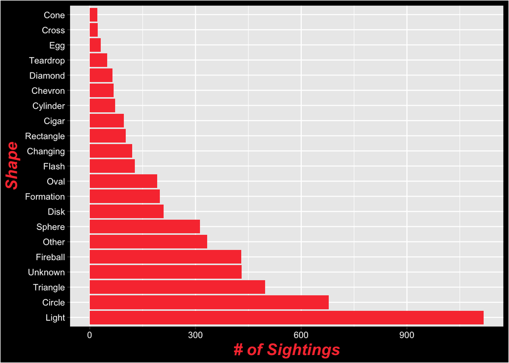

The most common shapes were *light*, *circle*, and *triangle*, which is likely due to observers only seeing the UFO for a small amount of time and being unable to discern a more complex shape, such as *teardrop*, *chevron*, etc.. However, there were still a surprisingly high amount of sightings that were reported to be of these complex-shaped UFOs.